# Quiz 04

Week 05

Please place your name(s) in the upper-right corner.

1. Write a for loop as syntactically accurate as you can if you wanted to index the ith value of the vector `vec <- c(1, 3, 5, 7, 9)` multiply it by 6, then save it in the empty vector `empty_vec <- rep(x = NA, times = length(vec))`.
2. For the following bifurcation diagram, please identify regions where $\lambda$ values lead to:
1. Chaos
2. Two-point oscillations/cycles
3. Damped oscillations/cycles
4. Extinction
5. Four-point oscillations/cycles  
   Note that one of the above are indecipherable from this figure 🤓.

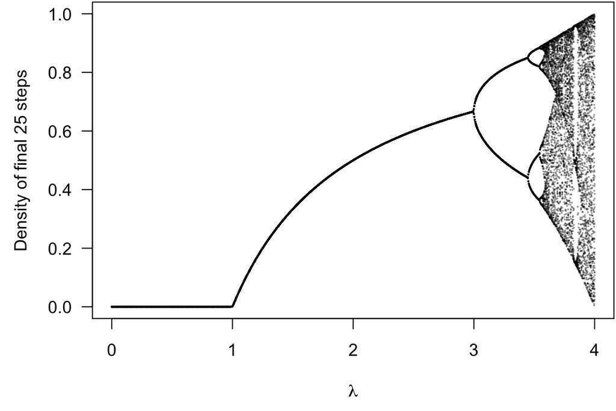

   (So very cute)
3. For the following Lotka-Volterra Predator-Prey model, match the coefficients with the definition:
   $$\begin{aligned}
   \frac{\mathrm{d}\Omega}{\mathrm{d}t} &= \alpha \diamondsuit \Omega -
   \spadesuit \Omega\\
   \frac{\mathrm{d}\alpha}{\mathrm{d}t} &= \clubsuit \alpha - \Omega
   \alpha \heartsuit
   \end{aligned}$$

| Coefficient | Meaning |
| --- | --- |
| $\clubsuit$ | Death rate of predators |
| $\heartsuit$ | Capture/attack rate of predators removing prey |
| $\spadesuit$ | Conversion rate of attacked prey to predators |
| $\diamondsuit$ | Intrinsic rate of growth of prey |

4. For the equation above, please find the equilibria for each each equation, separately. Note that now that we have 2 variables, $\Omega$ and $\alpha$, when you find equilibria for each, that we want the values of either variable that make the rate of change equal to 0.
5. For the equilibria you found for $d\Omega /dt = 0$, plot them on the left plot. For the equilibria you found for $d\alpha /dt = 0$, plot them on the right plot.

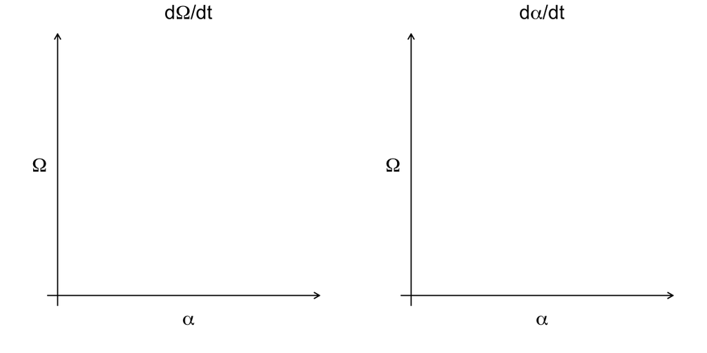